# Significance Testing R Functions

STAT 251 Section 01

This page is a directory of the R functions written for STAT 251. They cover the confidence intervals and significance tests we build by hand in class, and they print their results in the same order we write them on the board: hypotheses, estimate, standard error, critical value, interval, test statistic, p-value, decision.

You do **not** need any of this to do well in the course — everything here can be done with a calculator and a table. It is here if you want to check your arithmetic, or if you are curious how these calculations look in code.

## Getting the functions

Every function below lives in one file:

- stat251_tools.R (41 KB) — download this into your working folder

Save it next to your R script, then load all of it in one line:

```r
source('stat251_tools.R')
```

That is it — every function on this page is now available. If R replies `cannot open file 'stat251_tools.R'`, R is looking in a different folder than the one you saved it to. In RStudio, use **Session → Set Working Directory → To Source File Location** and run the line again.

A few conventions shared by all of them:

- `alpha` is the significance level, so `alpha = 0.05` gives a 95% interval.
- `test` picks the alternative hypothesis: `'lower.tail'`, `'upper.tail'` or `'two.tail'`.
- `verbose = TRUE` prints the full worked result. The test functions default to `TRUE`; the interval functions default to `FALSE` and just return the numbers.
- The functions take **summary statistics** (a mean, a standard deviation, a count), not raw data columns — the same numbers a problem gives you. The non-parametric tests are the exception, since ranks need the actual values.

# Picturing the test

Before the arithmetic, it helps to see what is being asked. `gen.density.plot()` draws the distribution of the test statistic when $H_0$ is true, shades the rejection region, and marks both the critical value and the statistic you observed. If the observed point lands in the shaded area, you reject.

```r
# Draws the distribution of the test statistic under H0, with the rejection
# region shaded and the critical value(s) and observed statistic labelled.
#   bbox     x-axis range to draw over
#   n        sample size - only used to get df = n - 1 when dist = 't'
#   dist     'z' for the standard normal, 't' for the t distribution
#   alpha    significance level, i.e. the area shaded
#   obs      the observed test statistic, marked on the axis
#   test     'two.tailed', 'lower.tail' or 'upper.tail'
#   shade    FALSE draws the curve with no shading
#   txt.sz   size of the axis labels
# Returns a ggplot object, so you can add to it or print it.
gen.density.plot=function(bbox = c(-4,4), n = 10, dist = c('z','t'), alpha = 0.05, obs = 0.5,
                          test = c('two.tailed','lower.tail', 'upper.tail'), shade = TRUE,
                          txt.sz = 5){
  test <- match.arg(test)
  dist <- match.arg(dist)

  p = ggplot(data.frame(x = bbox), aes(x = x))+
    theme_bw()
  if(shade == TRUE){
    p = p + stat_function(fun = d_limit,
                          args = list(alpha = alpha,
                                      test = test,
                                      dist = dist,
                                      n = n),
                          geom = "area",
                          fill = "cyan3",
                          alpha = 0.4)
  }
  if(dist == 'z'){
    q_a = qnorm(1-alpha)
    d_obs = dnorm(obs)
    d_a = dnorm(q_a)
    func = dnorm
    args = list()
    xlabel = "z"
  }else{
    q_a = qt(1-alpha, df = n-1)
    d_obs = dt(obs, df = n-1)
    d_a = dt(q_a, df = n-1)
    func = dt
    args = list(df = n-1)
    xlabel = 't'
  }

  if(test == 'two.tailed'){
    xcoords = c(-q_a, q_a, obs)
    ycoords = c(0,0,0)
    xendcoords = c(-q_a, q_a, obs)
    yendcoords = c(d_a, d_a, d_obs)
    if(dist == 'z'){
      lbl1 = c(TeX("$z_{\\alpha/2}$"),TeX("$z_{1-\\alpha/2}$"),TeX("$z_{obs}$"))
    }else{
      lbl1 = c(TeX("$t_{\\alpha/2}$"),TeX("$t_{1-\\alpha/2}$"),TeX("$t_{obs}$"))
    }
  }else if (test == 'upper.tail'){
    xcoords = c(q_a, obs)
    ycoords = c(0,0)
    xendcoords = c(q_a, obs)
    yendcoords = c(d_a, d_obs)
    if(dist == 'z'){
      lbl1 = c(TeX("$z_{1-\\alpha}$"),TeX("$z_{obs}$"))
    }else{
      lbl1 = c(TeX("$t_{1-\\alpha}$"),TeX("$t_{obs}$"))
    }
  }else{
    xcoords = c(-q_a, obs)
    ycoords = c(0,0)
    xendcoords = c(-q_a, obs)
    yendcoords = c(d_a, d_obs)
    if(dist == 'z'){
      lbl1 = c(TeX("$z_{\\alpha}$"), TeX("$z_{obs}$"))
    }else{
      lbl1 = c(TeX("$t_{\\alpha}$") ,TeX("$t_{obs}$"))
    }
  }

  if(test == 'two.tailed'){
    final = p+stat_function(fun = func,
                            args = args,
                            size = 1)+
      geom_segment(aes(x=xcoords[1:2],
                       y=ycoords[1:2],
                       xend=xendcoords[1:2],
                       yend=yendcoords[1:2]),
                   size = 0.9,
                   linetype = 'dashed')+
      geom_segment(aes(x=xcoords[3],
                       y=ycoords[3],
                       xend=xendcoords[3],
                       yend=yendcoords[3]),
                   size = 0.9,
                   linetype = 'dashed')+
      geom_point(aes(x = xcoords[1:2], y = ycoords[1:2]), size = 3)+
      geom_label(aes(x = xcoords[1:2], y = ycoords[1:2]-0.025), label = lbl1[1:2], size = txt.sz)+
      geom_point(aes(x = xcoords[3], y = ycoords[3]), size = 3)+
      geom_label(aes(x = xcoords[3], y = ycoords[3]-0.025), label = lbl1[3], size = txt.sz)+
      geom_hline(yintercept = 0, size = 1)+
      xlab(xlabel)+
      ylab('Probability Density')+
      ggtitle(TeX('Distribution under $H_0$'))+
      theme(axis.title.x = element_text(size = 14),
            axis.title.y = element_text(size = 14))
  }else{
    final = p+stat_function(fun = func,
                            args = args,
                            size = 1)+
      geom_segment(aes(x=xcoords,
                       y=ycoords,
                       xend=xendcoords,
                       yend=yendcoords),
                   size = rep(0.9, length(xcoords)),
                   linetype = rep('dashed',length(xcoords)))+
      geom_point(aes(x = xcoords, y = ycoords), size = 3)+
      geom_label(aes(x = xcoords, y = ycoords-0.025), label = lbl1, size = txt.sz)+
      geom_hline(yintercept = 0, size = 1)+
      xlab(xlabel)+
      ylab('Probability Density')+
      ggtitle(TeX('Distribution under $H_0$'))+
      theme(axis.title.x = element_text(size = 12),
            axis.title.y = element_text(size = 12))
  }


  return(final)
}
```

`d_limit()` is its helper. It returns the height of the curve, but `NA` for every x outside the rejection region — and since `ggplot` silently skips `NA`s, the shading lands only on the tail(s).

```r
# Helper for gen.density.plot() - not meant to be called on its own.
# Returns the density at x, but NA everywhere OUTSIDE the rejection region.
# ggplot skips NA values, so the shaded area lands only on the tail(s).
d_limit <- function(x, alpha, test, dist, n) {
  test <- match.arg(test, c('two.tailed', 'upper.tail', 'lower.tail'))
  if(dist == 'z'){
    y = dnorm(x)
    q_a = qnorm(1-alpha)
  }else{
    y = dt(x, df = n-1)
    q_a = qt(1-alpha, df = n-1)
  }


  if(test == 'two.tailed'){
    y[which(x>-q_a & x<q_a)] <- NA
    return(y)
  }else if (test == 'upper.tail'){
    y[which(x < q_a)] <- NA
    return(y)
  }else{
    y[which(x > -q_a)] <- NA
    return(y)
  }

}
```

**Example.** A one-tailed z test at $\alpha = 0.05$ with an observed statistic of 2.1. The critical value is 1.645, the observed value is past it, so this is a rejection:

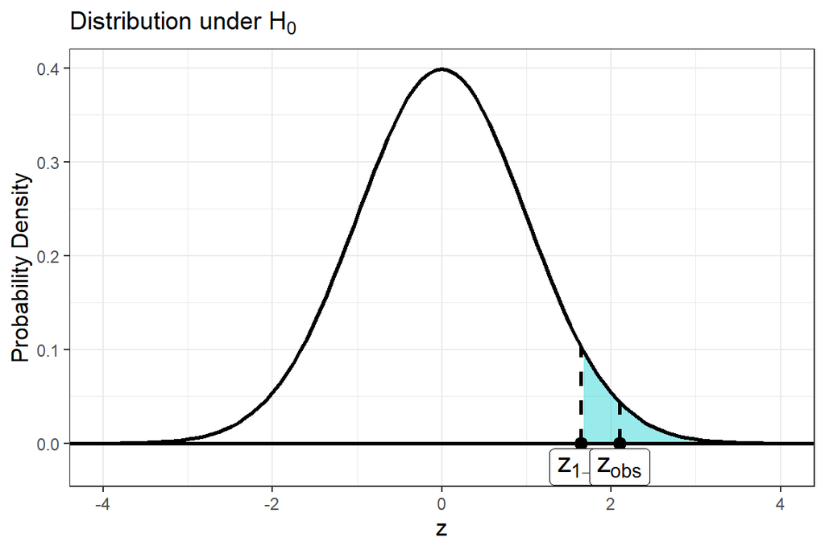

```r
gen.density.plot(dist = 'z', alpha = 0.05, obs = 2.1, test = 'upper.tail')
```

The same picture for a t test with 15 observations — note the heavier tails, which push the critical value further out than the z:

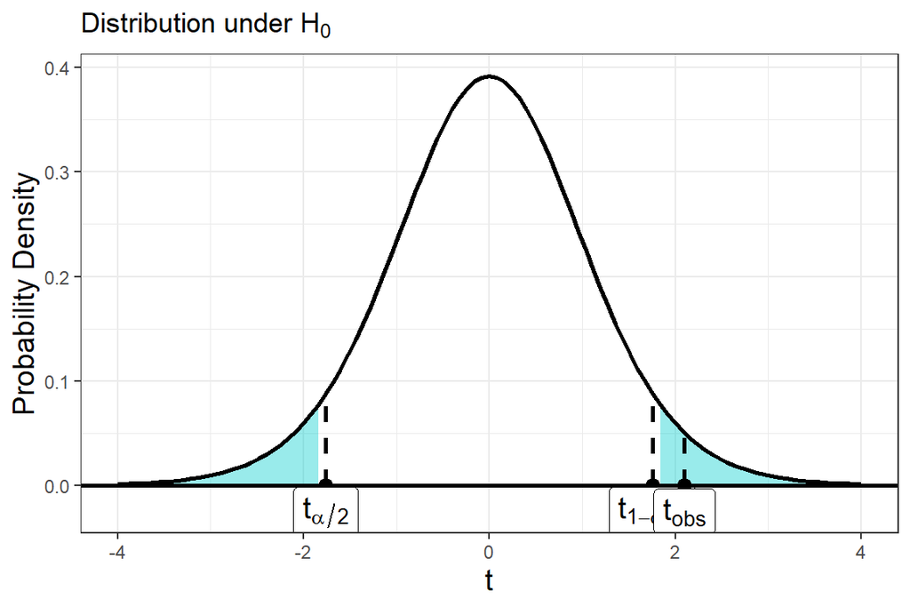

```r
gen.density.plot(dist = 't', n = 15, alpha = 0.05, obs = 2.1, test = 'two.tailed')
```

# One sample: a proportion

Use these when the question is about a **percentage or a fraction** of one group — what share of students own a car, whether a coin is fair.

## Standard error

```r
# Standard error of a sample proportion: SE = sqrt(phat(1-phat)/n).
one.sample.prop.SE = function(phat, n){
  SE = sqrt((phat*(1-phat))/n)
  return(SE)
}
```

## Confidence interval

```r
# Confidence interval for a population proportion.
#   phat     the sample proportion
#   n        the sample size
#   alpha    1 - alpha is the confidence level
#   verbose  TRUE prints the pieces of the calculation
# Returns c(lower.bound, upper.bound). Unlike the test above, the SE here is
# computed from phat - a confidence interval has no null value to lean on.
one.sample.prop.CI = function(phat, n, alpha = 0.05, verbose = FALSE){
  SE = one.sample.prop.SE(phat, n)
  standard.score = qnorm(1-(alpha/2))
  MOE = standard.score*SE
  lower.bound = phat-MOE
  upper.bound = phat+MOE
  if(isTRUE(verbose)){
    print(noquote(paste0(rep('-', 50), collapse = '')))
    print(noquote(paste0('Estimate = ', round(phat, 4))))
    print(noquote(paste0('Critical Value  = ', round(standard.score, 4))))
    print(noquote(paste0('Estimated Standard Error = ', round(SE, 4))))
    print(noquote(paste0('Margin of error = ', round(MOE, 4))))
    print(noquote(paste0((1-alpha)*100, ' % CI = ', paste0('[', round(max(lower.bound,0),4), ',',
                                             round(min(upper.bound, 1), 4), ']',
                                             collapse = ''))))
    print(noquote(paste0(rep('-', 50), collapse = '')))
  }
  return(c(lower.bound, upper.bound))
}
```

## Test

```r
# One-sample z test for a population proportion.
#   p0       hypothesized proportion under H0
#   phat     the sample proportion
#   n        the sample size
#   alpha    significance level
#   test     'lower.tail', 'upper.tail' or 'two.tail'
#   verbose  TRUE prints the results
# The test statistic uses the SE computed from p0, not from phat, because
# the null hypothesis is assumed true while testing.
one.sample.prop.test = function(p0, phat, n, alpha = 0.05, test = c('lower.tail','upper.tail','two.tail'),
                                verbose = TRUE){
  test <- match.arg(test)

  estimate.SE = one.sample.prop.SE(p0, n)
  Zobs = (phat - p0)/estimate.SE
  if(test == 'two.tail'){
    critical.value = qnorm((1-(alpha/2)))
    alt.hyp = 'p != '
    pvalue = 2*(1-pnorm(abs(Zobs)))
  }else if(test == 'lower.tail'){
    critical.value = qnorm(alpha)
    alt.hyp = 'p < '
    pvalue = pnorm(Zobs)
  }else{
    critical.value = qnorm(1-alpha)
    alt.hyp = 'p > '
    pvalue = 1-pnorm(Zobs)
  }

  CI = one.sample.prop.CI(phat, n, alpha)
  decision = ifelse(pvalue<alpha, 'reject H0', 'fail to reject H0')
  if(isTRUE(verbose)){
    print(noquote(paste0(paste0(rep('=', 20), collapse = ''), ' test results ', paste0(rep('=', 20), collapse = ''))))
    print(noquote(paste0('test type = ', test)))
    print(noquote(paste0('H0: p0 = ', p0)))
    print(noquote(paste0('HA: ', alt.hyp, p0)))
    print(noquote(paste0('estimate = ', round(phat,4))))
    print(noquote(paste0('Estimated Standard Error = ', round(estimate.SE,4))))
    print(noquote(paste0('Critical Value = ', round(critical.value, 4))))
    print(noquote(paste0((1-alpha)*100, '% CI = ', paste0('[', max(round(CI[1],4), 0),',',
                                                  round(CI[2],4),']',
                                                  collapse = ''))))
    print(noquote(paste0('Test statistic = ', round(Zobs, 4))))
    print(noquote(paste0('Pvalue = ', round(pvalue, 4))))
    print(noquote(paste0('Decision: ', decision)))
    print(noquote(paste0(rep("=", 54), collapse = '')))
  }
}
```

**Example.** In a sample of 100 students, 62 said they own a car. Is that evidence that more than half of all students own one?

```r
one.sample.prop.test(p0 = 0.5, phat = 0.62, n = 100, test = 'upper.tail')
```

```
## [1] ==================== test results ====================
## [1] test type = upper.tail
## [1] H0: p0 = 0.5
## [1] HA: p > 0.5
## [1] estimate = 0.62
## [1] Estimated Standard Error = 0.05
## [1] Critical Value = 1.6449
## [1] 95% CI = [0.5249,0.7151]
## [1] Test statistic = 2.4
## [1] Pvalue = 0.0082
## [1] Decision: reject H0
## [1] ======================================================
```

The p-value is 0.0082, well under 0.05, so we reject $H_0$.

Note that the standard error printed here (0.05) is computed from $p_0 = 0.5$, not from $\hat p = 0.62$. While we are testing, we assume $H_0$ is true. The confidence interval makes the opposite choice — it has no null value to lean on, so it uses $\hat p$:

```r
one.sample.prop.CI(phat = 0.62, n = 100, alpha = 0.05, verbose = TRUE)
```

```
## [1] --------------------------------------------------
## [1] Estimate = 0.62
## [1] Critical Value  = 1.96
## [1] Estimated Standard Error = 0.0485
## [1] Margin of error = 0.0951
## [1] 95 % CI = [0.5249,0.7151]
## [1] --------------------------------------------------
```

```
## [1] 0.524866 0.715134
```

# One sample: a mean

Use these when the question is about an **average** of one group — mean study time, mean height — and the population standard deviation is unknown, which in practice is always.

## Standard error

```r
# Standard error of a sample mean: SE = s / sqrt(n).
one.sample.t.SE = function(s, n){
  SE = s/sqrt(n)
  return(SE)
}
```

## Confidence interval

```r
# Confidence interval for a population mean.
#   xbar     the sample mean
#   s        the sample standard deviation
#   n        the sample size
#   alpha    1 - alpha is the confidence level
#   verbose  TRUE prints the pieces of the calculation
# Returns c(lower.bound, upper.bound).
one.sample.t.CI = function(xbar, s, n, alpha = 0.05, verbose = FALSE){
  SE = one.sample.t.SE(s, n)
  t.score = qt(1-(alpha/2), df = n-1)
  MOE = t.score*SE
  lower.bound = xbar-MOE
  upper.bound = xbar+MOE
  if(isTRUE(verbose)){
    print(noquote(paste0(rep('-', 50), collapse = '')))
    print(noquote(paste0('Estimate = ', round(xbar, 4))))
    print(noquote(paste0('Critical Value  = ', round(t.score, 4))))
    print(noquote(paste0('Estimated Standard Error = ', round(SE, 4))))
    print(noquote(paste0('Margin of error = ', round(MOE, 4))))
    print(noquote(paste0((1-alpha)*100, ' % CI = ', paste0('[', round(lower.bound,4),',',
                                             round(upper.bound,4), ']',
                                             collapse = ''))))
    print(noquote(paste0(rep('-', 50), collapse = '')))
  }
  return(c(lower.bound, upper.bound))
}
```

## Test

```r
# One-sample t test for a population mean.
#   m0       hypothesized mean under H0
#   xbar     the sample mean
#   s        the sample standard deviation
#   n        the sample size
#   alpha    significance level
#   test     'lower.tail', 'upper.tail' or 'two.tail'
#   verbose  TRUE prints the results
# Prints the results and returns nothing.
one.sample.t.test = function(m0, xbar, s, n, alpha = 0.05, test = c('lower.tail','upper.tail','two.tail'),
                             verbose = TRUE){
  test <- match.arg(test)

  df = n - 1
  estimate.SE = one.sample.t.SE(s, n)
  tobs = (xbar - m0)/estimate.SE
  if(test == 'two.tail'){
    critical.value = qt((1-(alpha/2)), df = df)
    alt.hyp = 'm != '
    pvalue = 2*(1-pt(abs(tobs), df = df))
  }else if(test == 'lower.tail'){
    critical.value = qt(alpha, df = df)
    alt.hyp = 'm < '
    pvalue = pt(tobs, df = df)
  }else{
    critical.value = qt(1-alpha, df = df)
    alt.hyp = 'm > '
    pvalue = 1-pt(tobs, df = df)
  }

  CI = one.sample.t.CI(xbar, s, n, alpha)
  decision = ifelse(pvalue<alpha, 'reject H0', 'fail to reject H0')
  if(isTRUE(verbose)){
    print(noquote(paste0(paste0(rep('=', 20), collapse = ''), ' test results ', paste0(rep('=', 20), collapse = ''))))
    print(noquote(paste0('test type = ', test)))
    print(noquote(paste0('H0: m0 = ', m0)))
    print(noquote(paste0('HA: ', alt.hyp, m0)))
    print(noquote(paste0('Estimate = ', round(xbar,4))))
    print(noquote(paste0('Estimated Standard Error = ', round(estimate.SE,4))))
    print(noquote(paste0('Critical Value = ', round(critical.value, 4))))
    print(noquote(paste0((1-alpha)*100, '% CI = ', paste0('[', max(round(CI[1],4), 0),',',
                                                  round(CI[2],4),']',
                                                  collapse = ''))))
    print(noquote(paste0('Test statistic = ', round(tobs, 4))))
    print(noquote(paste0('Degrees of Freedom = ', round(df, 4))))
    print(noquote(paste0('Pvalue = ', round(pvalue, 4))))
    print(noquote(paste0('Decision: ', decision)))
    print(noquote(paste0(rep("=", 54), collapse = '')))
  }
}
```

**Example.** 25 students studied a mean of 13.2 hours a week with a standard deviation of 5.4 hours. Is the true mean different from 12?

```r
one.sample.t.test(m0 = 12, xbar = 13.2, s = 5.4, n = 25, test = 'two.tail')
```

```
## [1] ==================== test results ====================
## [1] test type = two.tail
## [1] H0: m0 = 12
## [1] HA: m != 12
## [1] Estimate = 13.2
## [1] Estimated Standard Error = 1.08
## [1] Critical Value = 2.0639
## [1] 95% CI = [10.971,15.429]
## [1] Test statistic = 1.1111
## [1] Degrees of Freedom = 24
## [1] Pvalue = 0.2775
## [1] Decision: fail to reject H0
## [1] ======================================================
```

The p-value is 0.2775, so we fail to reject $H_0$. Consistent with that, the 95% interval contains 12:

```r
one.sample.t.CI(xbar = 13.2, s = 5.4, n = 25, alpha = 0.05, verbose = TRUE)
```

```
## [1] --------------------------------------------------
## [1] Estimate = 13.2
## [1] Critical Value  = 2.0639
## [1] Estimated Standard Error = 1.08
## [1] Margin of error = 2.229
## [1] 95 % CI = [10.971,15.429]
## [1] --------------------------------------------------
```

```
## [1] 10.97099 15.42901
```

# Two samples: proportions

Use these to **compare a percentage between two groups**.

## Standard error

```r
# Unpooled standard error of a difference between two sample proportions:
# SE = sqrt(p1(1-p1)/n1 + p2(1-p2)/n2).
two.sample.prop.SE = function(p1,p2,n1,n2){
  SE = sqrt((p1*(1-p1)/n1)+(p2*(1-p2)/n2))
  return(SE)
}
```

## Confidence interval

```r
# Confidence interval for the difference between two population proportions.
#   p1, p2   the two sample proportions
#   n1, n2   the two sample sizes
#   tail     'two.tail' for a two-sided interval, anything else one-sided
#   alpha    1 - alpha is the confidence level
#   verbose  TRUE prints the pieces of the calculation
# Returns a list: estimate, interval, margin.of.error, critical.value.
two.sample.prop.CI = function(p1,p2,n1,n2,tail = 'two.tail',alpha = 0.05, verbose = FALSE){
  diff = p1-p2
  bounds=c(0,0)
  if(tail != 'two.tail'){
    Z = qnorm(1-alpha)
  }else{
    Z = qnorm(1-(alpha/2))
  }
  SE = two.sample.prop.SE(p1,p2,n1,n2)
  MOE = Z*SE
  bounds[1] = diff - MOE
  bounds[2] = diff + MOE
  bounds = sort(bounds)
  if(isTRUE(verbose)){
    print(noquote(paste0(rep('-', 50), collapse = '')))
    print(noquote(paste0('Estimate = ', round(diff, 4))))
    print(noquote(paste0('Critical Value  = ', round(Z, 4))))
    print(noquote(paste0('Estimated Standard Error = ', round(SE, 4))))
    print(noquote(paste0('Margin of error = ', round(MOE, 4))))
    print(noquote(paste0((1-alpha)*100, ' % CI = ', paste0('[',round(bounds[1], 4), ',',
                                                   round(bounds[2], 4), ']'))))
    print(noquote(paste0(rep('-', 50), collapse = '')))
  }

  return(list(estimate = diff, interval = bounds, margin.of.error = MOE, critical.value = Z))
}
```

## Test

```r
# Two-sample z test for a difference between two population proportions.
#   p0       difference under H0 (usually 0)
#   x1, x2   the two SUCCESS COUNTS (not proportions)
#   n1, n2   the two sample sizes
#   alpha    significance level
#   test     'lower.tail', 'upper.tail' or 'two.tail'
#   pooled   TRUE uses the pooled SE, which is the right choice when H0 says
#            the two proportions are equal; FALSE uses the unpooled SE
#   verbose  TRUE prints the results
# Note the interval is always built from the UNPOOLED SE, since a confidence
# interval does not assume H0 is true.
two.sample.prop.test = function(p0,x1,x2,n1,n2,alpha = 0.05, test = c('lower.tail','upper.tail','two.tail'),
                                pooled = TRUE, verbose = TRUE){
  test <- match.arg(test)


  p1 = x1/n1
  p2 = x2/n2
  estimate = p1 - p2
  estimate.SE = two.sample.prop.SE(p1, p2, n1, n2)
  if(isTRUE(pooled)){
    # H0 says the two proportions are equal, so under H0 there is really only
    # ONE proportion to estimate - pool both samples into a single estimate.
    calc = 'pooled'
    p.pooled = (x1+x2)/(n1+n2)
    test.SE = sqrt( (p.pooled*(1-p.pooled))*(1/n1 + 1/n2) )
  }else{
    calc = 'unpooled'
    test.SE = two.sample.prop.SE(p1,p2,n1,n2)
  }
  Zobs = (estimate - p0)/test.SE
  if(test == 'two.tail'){
    critical.value = qnorm((1-(alpha/2)))
    alt.hyp = 'p1 - p2 != '
    pvalue = 2*(1-pnorm(abs(Zobs)))
  }else if(test == 'lower.tail'){
    critical.value = qnorm(alpha)
    alt.hyp = 'p1 - p2 < '
    pvalue = pnorm(Zobs)
  }else{
    critical.value = qnorm(1-alpha)
    alt.hyp = 'p1 - p2 > '
    pvalue = 1-pnorm(Zobs)
  }

  CI = sort(c(estimate - critical.value * estimate.SE, estimate + critical.value * estimate.SE))
  decision = ifelse(pvalue<alpha, 'reject H0', 'fail to reject H0')
  if(isTRUE(verbose)){
    print(noquote(paste0(paste0(rep('=', 20), collapse = ''), ' test results ', paste0(rep('=', 20), collapse = ''))))
    print(noquote(paste0('test type = ', test)))
    print(noquote(paste0('H0: p1 - p2 = ', p0)))
    print(noquote(paste0('HA: ', alt.hyp, p0)))
    print(noquote(paste0('estimate = ', round(estimate,4))))
    print(noquote(paste0(calc,' SE = ', round(test.SE,4))))
    print(noquote(paste0((1-alpha)*100, '% CI = ', paste0('[', max(round(CI[1],4), 0),',',
                                                  round(CI[2],4),']',
                                                  collapse = ''))))
    print(noquote(paste0('Critical Value = ', round(critical.value,4))))
    print(noquote(paste0('Test statistic = ', round(Zobs, 4))))
    print(noquote(paste0('Pvalue = ', round(pvalue, 4))))
    print(noquote(paste0('Decision: ', decision)))
    print(noquote(paste0(rep("=", 54), collapse = '')))
  }
}
```

**Example.** 45 of 80 students in one group and 30 of 90 in another answered yes. Note this function wants the **counts**, not the proportions:

```r
two.sample.prop.test(p0 = 0, x1 = 45, n1 = 80, x2 = 30, n2 = 90, test = 'two.tail')
```

```
## [1] ==================== test results ====================
## [1] test type = two.tail
## [1] H0: p1 - p2 = 0
## [1] HA: p1 - p2 != 0
## [1] estimate = 0.2292
## [1] pooled SE = 0.0763
## [1] 95% CI = [0.0832,0.3751]
## [1] Critical Value = 1.96
## [1] Test statistic = 3.0037
## [1] Pvalue = 0.0027
## [1] Decision: reject H0
## [1] ======================================================
```

`pooled = TRUE` is the default and is usually what you want: $H_0$ says the two proportions are equal, so under $H_0$ there is only one proportion to estimate and both samples can be pooled into it. The interval is always built from the *unpooled* standard error, because an interval does not assume $H_0$ is true.

# Two samples: means

Use these to **compare an average between two groups**.

## Standard error

```r
# Unpooled standard error of a difference between two sample means:
# SE = sqrt(s1^2/n1 + s2^2/n2). Variances add even though we subtract means.
two.sample.t.SE = function(s1,s2,n1,n2){
  SE = sqrt((s1^2/n1)+(s2^2/n2))
  return(SE)
}
```

## Confidence interval

```r
# Confidence interval for the difference between two population means.
#   x1, x2   the two sample means
#   s1, s2   the two sample standard deviations
#   n1, n2   the two sample sizes
#   tail     'two.tail' for a two-sided interval, anything else one-sided
#   alpha    1 - alpha is the confidence level
#   verbose  TRUE prints the pieces of the calculation
# Returns a list: estimate, interval, margin.of.error, critical.value.
# Uses the conservative df = min(n1, n2) - 1 rather than Welch's formula.
two.sample.t.CI = function(x1,x2,s1,s2,n1,n2, tail = 'two.tail',alpha = 0.05, verbose = FALSE){
  diff = x1-x2
  bounds=c(0,0)
  df = min(n1-1, n2-1)
  if(tail != 'two.tail'){
    t.crit = qt(1-alpha, df = df)
  }else{
    t.crit = qt(1-(alpha/2), df = df)
  }
  SE = two.sample.t.SE(s1,s2,n1,n2)
  MOE = t.crit*SE
  bounds[1] = diff - MOE
  bounds[2] = diff + MOE
  bounds = sort(bounds)
  if(isTRUE(verbose)){
    print(noquote(paste0(rep('-', 50), collapse = '')))
    print(noquote(paste0('Estimate = ', round(diff, 4))))
    print(noquote(paste0('Critical Value  = ', round(t.crit, 4))))
    print(noquote(paste0('Estimated Standard Error = ', round(SE, 4))))
    print(noquote(paste0('Margin of error = ', round(MOE, 4))))
    print(noquote(paste0((1-alpha)*100, ' % CI = ', paste0('[',round(bounds[1], 4), ',',
                                                   round(bounds[2], 4), ']'))))
    print(noquote(paste0(rep('-', 50), collapse = '')))
  }

  return(list(estimate = diff, interval = bounds, margin.of.error = MOE, critical.value = t.crit))
}
```

## Test

```r
# Two-sample t test for a difference between two population means.
#   m0       difference under H0 (usually 0)
#   x1, x2   the two sample means
#   s1, s2   the two sample standard deviations
#   n1, n2   the two sample sizes
#   alpha    significance level
#   test     'lower.tail', 'upper.tail' or 'two.tail'
#   pooling  'pooled' (assume equal variances), 'unpooled' (Welch), or
#            'approx.unpooled' (Welch SE with the easy df = min(n1,n2) - 1)
#   verbose  TRUE prints the results
# Prints the results and returns nothing.
two.sample.t.test = function(m0,x1,x2,s1,s2,n1,n2,alpha = 0.05, test = c('lower.tail','upper.tail','two.tail'),
                             pooling = c('pooled', 'unpooled','approx.unpooled'), verbose = TRUE){
  test <- match.arg(test)
  pooling <- match.arg(pooling)

  estimate = x1 - x2
  estimate.SE = two.sample.t.SE(s1, s2, n1, n2)
  if(pooling == 'pooled'){
    # Equal variances assumed: average the two sample variances, weighted by
    # their degrees of freedom, into one pooled estimate. Buys the full
    # n1 + n2 - 2 degrees of freedom.
    calc = 'pooled'
    df = n1 + n2 - 2
    s.pooled = sqrt( ((n1-1)*s1^2 + (n2-1)*s2^2)/(n1+n2-2))
    test.SE = s.pooled * sqrt((1/n1)+(1/n2))
  }else if (pooling == 'unpooled'){
    # Variances NOT assumed equal. The Welch-Satterthwaite formula below is the
    # ugly one from the book - it usually lands on a fractional df, which is
    # normal and not a mistake.
    calc = 'unpooled'
    df = (((s1^2/n1)+(s2^2/n2))^2)/(((s1^2/n1)^2/(n1-1)) + ((s2^2/n2)^2/(n2-1)))
    test.SE = two.sample.t.SE(s1,s2,n1,n2)
  }else{
    calc = 'approx.unpooled'
    df = min(n1-1, n2-1)
    test.SE = two.sample.t.SE(s1,s2,n1,n2)
  }
  tobs = (estimate - m0)/test.SE
  if(test == 'two.tail'){
    critical.value = qt((1-(alpha/2)), df = df)
    alt.hyp = 'm1 - m2 != '
    pvalue = 2*(1-pt(abs(tobs), df = df))
  }else if(test == 'lower.tail'){
    critical.value = qt(alpha, df = df)
    alt.hyp = 'm1 - m2 < '
    pvalue = pt(tobs, df = df)
  }else{
    critical.value = qt(1-alpha, df = df)
    alt.hyp = 'm1 - m2 > '
    pvalue = 1-pt(tobs, df = df)
  }

  CI = sort(c(estimate - critical.value * estimate.SE, estimate + critical.value * estimate.SE))
  decision = ifelse(pvalue<alpha, 'reject H0', 'fail to reject H0')
  if(isTRUE(verbose)){
    print(noquote(paste0(paste0(rep('=', 20), collapse = ''), ' test results ', paste0(rep('=', 20), collapse = ''))))
    print(noquote(paste0('test type = ', test)))
    print(noquote(paste0('H0: m1 - m2 = ', m0)))
    print(noquote(paste0('HA: ', alt.hyp, m0)))
    print(noquote(paste0('estimate = ', round(estimate,4))))
    print(noquote(paste0(calc,' SE = ', round(test.SE,4))))
    print(noquote(paste0((1-alpha)*100, '% CI = ', paste0('[',round(CI[1],4),',',
                                                  round(CI[2],4),']',
                                                  collapse = ''))))
    print(noquote(paste0('Critical Value = ', round(critical.value,4))))
    print(noquote(paste0('Test statistic = ', round(tobs, 4))))
    print(noquote(paste0('degrees of freedom = ', round(df, 4))))
    print(noquote(paste0('Pvalue = ', round(pvalue, 4))))
    print(noquote(paste0('Decision: ', decision)))
    print(noquote(paste0(rep("=", 54), collapse = '')))
  }
}
```

**Example.** Group 1: mean 13.2, sd 5.4, n = 25. Group 2: mean 10.8, sd 4.9, n = 30.

```r
two.sample.t.test(m0 = 0, x1 = 13.2, x2 = 10.8, s1 = 5.4, s2 = 4.9,
                  n1 = 25, n2 = 30, test = 'two.tail', pooling = 'unpooled')
```

```
## [1] ==================== test results ====================
## [1] test type = two.tail
## [1] H0: m1 - m2 = 0
## [1] HA: m1 - m2 != 0
## [1] estimate = 2.4
## [1] unpooled SE = 1.4024
## [1] 95% CI = [-0.4181,5.2181]
## [1] Critical Value = 2.0095
## [1] Test statistic = 1.7113
## [1] degrees of freedom = 49.1028
## [1] Pvalue = 0.0933
## [1] Decision: fail to reject H0
## [1] ======================================================
```

The `pooling` argument chooses how to handle the two standard deviations:

- `'pooled'` — assume the two populations have equal variances. Combines them into one estimate and gets the full $n_1 + n_2 - 2$ degrees of freedom.
- `'unpooled'` — do not assume that. Uses the Welch–Satterthwaite formula, which usually gives a fractional degrees of freedom (49.1 above). That is normal.
- `'approx.unpooled'` — the same standard error with the easy hand-calculation shortcut $df = \min(n_1, n_2) - 1$, which is what we use on paper.

Switching to the pooled version on the same data barely moves the answer, which is typical when the two sample standard deviations are close:

```r
two.sample.t.test(m0 = 0, x1 = 13.2, x2 = 10.8, s1 = 5.4, s2 = 4.9,
                  n1 = 25, n2 = 30, test = 'two.tail', pooling = 'pooled')
```

```
## [1] ==================== test results ====================
## [1] test type = two.tail
## [1] H0: m1 - m2 = 0
## [1] HA: m1 - m2 != 0
## [1] estimate = 2.4
## [1] pooled SE = 1.3899
## [1] 95% CI = [-0.4129,5.2129]
## [1] Critical Value = 2.0057
## [1] Test statistic = 1.7268
## [1] degrees of freedom = 53
## [1] Pvalue = 0.09
## [1] Decision: fail to reject H0
## [1] ======================================================
```

# Non-parametric tests

These make no assumption that the data are normal. They work on **signs and ranks** instead of the actual measurements, which costs some power but survives outliers and small samples. Unlike the functions above, these need the raw data.

## The sign test

Throws away how big each difference is and keeps only whether it was positive or negative, then tests those signs as a proportion. Pairs that tie exactly are dropped, so the number of signs can be smaller than the number of pairs.

```r
# The sign test for paired data: throw away how BIG each difference is and
# keep only whether it was + or -, then test those signs as a proportion.
#   p0       proportion of + signs under H0 (usually 0.5)
#   x1, x2   the two paired samples
#   alpha    significance level
#   test     'lower.tail', 'upper.tail' or 'two.tail'
#   verbose  TRUE prints the results
# P-values come from the exact binomial, not a normal approximation.
sign.test = function(p0, x1, x2, alpha = 0.05, test = c('lower.tail','upper.tail','two.tail'),
                     verbose = TRUE){
  test <- match.arg(test)

  diffs = x1 - x2
  # Pairs that tied (difference exactly 0) get no sign, so they are counted in
  # neither total - which is why total.signs can be smaller than length(x1).
  total.signs = sum(diffs>0)+sum(diffs<0)
  positive.signs = sum(diffs>0)

  phat = positive.signs/total.signs
  SE = sqrt(phat*(1-phat)/total.signs)
  if(test == 'two.tail'){
    upper.bound = qbinom(1-(alpha/2), total.signs, phat)
    lower.bound = qbinom(alpha/2, total.signs, phat)
    alt.hyp = 'p != '
    pvalue = 2*(1-pbinom(positive.signs-1, total.signs, p0))
    if(pvalue > 1){
      pvalue = 1
    }
  }else if(test == 'lower.tail'){
    upper.bound = qbinom(1-alpha/2, total.signs, phat)
    lower.bound = qbinom(alpha/2, total.signs, phat)
    alt.hyp = 'p < '
    pvalue = pbinom(positive.signs, total.signs, p0)
  }else{
    upper.bound = qbinom(1-(alpha/2), total.signs, phat)
    lower.bound = qbinom(alpha/2, total.signs, phat)
    alt.hyp = 'p > '
    pvalue = 1-pbinom(positive.signs-1, total.signs, p0)
  }

  CI = c(lower.bound/total.signs, upper.bound/total.signs)
  decision = ifelse(pvalue<alpha, 'reject H0', 'fail to reject H0')
  if(isTRUE(verbose)){
    print(noquote(paste0(paste0(rep('=', 20), collapse = ''), ' test results ', paste0(rep('=', 20), collapse = ''))))
    print(noquote(paste0('test type = ', test)))
    print(noquote(paste0('H0: p0 = ', p0)))
    print(noquote(paste0('HA: ', alt.hyp, p0)))
    print(noquote(paste0('# of positive signs = ', positive.signs)))
    print(noquote(paste0('# of total signs = ', total.signs)))
    print(noquote(paste0('Estimated P(+ sign) = ', round(phat, 4))))
    print(noquote(paste0('Estimated Standard Error P(+ sign) = ', round(SE,4))))
    print(noquote(paste0((1-alpha)*100, '% CI P(+ sign) = ', paste0('[', round(CI[1],4),',',
                                                            round(CI[2],4),']',
                                                            collapse = ''))))
    print(noquote(paste0('Pvalue = ', round(pvalue, 4))))
    print(noquote(paste0('Decision: ', decision)))
    print(noquote(paste0(rep("=", 54), collapse = '')))

  }
}
```

**Example.** Ten students’ resting heart rate before and after a program:

```r
before <- c(72, 68, 75, 80, 66, 71, 79, 74, 70, 77)
after  <- c(70, 69, 71, 74, 65, 68, 73, 74, 66, 72)

sign.test(p0 = 0.5, x1 = before, x2 = after, test = 'upper.tail')
```

```
## [1] ==================== test results ====================
## [1] test type = upper.tail
## [1] H0: p0 = 0.5
## [1] HA: p > 0.5
## [1] # of positive signs = 8
## [1] # of total signs = 9
## [1] Estimated P(+ sign) = 0.8889
## [1] Estimated Standard Error P(+ sign) = 0.1048
## [1] 95% CI P(+ sign) = [0.6667,1]
## [1] Pvalue = 0.0195
## [1] Decision: reject H0
## [1] ======================================================
```

Eight of the ten differences were positive; one student tied and was dropped, leaving 9 signs. The p-value of 0.0195 comes from the exact binomial, not a normal approximation.

## Wilcoxon rank-sum test (independent samples)

The non-parametric stand-in for the two-sample t test. Pool both samples, rank everything from smallest to largest, then add up the ranks belonging to the first sample.

```r
# Rank-sum statistic S: pool both samples, rank them from smallest to
# largest, then add up the ranks that belong to X.
#   X, Y  the two independent samples
# Returns the single number S.
rank.sum.stat=function(X, Y){
  D = sort(c(X, Y), decreasing = FALSE)
  ranks = match(X,D)
  S = sum(ranks)
  return(S)
}
```

```r
# Wilcoxon rank-sum (Mann-Whitney) test for two INDEPENDENT samples - the
# non-parametric stand-in for the two-sample t test.
#   m0        location shift under H0 (usually 0)
#   X, Y      the two samples; or supply S, n1 and n2 instead
#   S         a precomputed rank sum for sample X
#   n1, n2    the two sample sizes, required only when S is given directly
#   alpha     significance level
#   test      'lower.tail', 'upper.tail' or 'two.tail'
#   verbose   TRUE prints the results
# Prints the results and returns nothing.
Wilcoxon.rank.sum.test = function(m0, X=NULL, Y=NULL, S=NULL, n1=NULL, n2=NULL, alpha = 0.05,
                                  test = c('lower.tail','upper.tail','two.tail'), verbose = TRUE){
  test <- match.arg(test)

  if(is.null(S)){
    S = rank.sum.stat(X,Y)
    n1 = length(X)
    n2 = length(Y)
  }

  # Convert the rank sum S into the Mann-Whitney U by subtracting the smallest
  # rank sum sample X could possibly have had (1 + 2 + ... + n1). R's wilcox
  # distribution functions are written in terms of U, not S.
  U = S - (n1*(n1+1))/2
  if(test == 'two.tail'){
    upper.bound = qwilcox(1-(alpha/2), n1, n2)
    lower.bound = qwilcox(alpha/2, n1, n2)
    alt.hyp = 'true location shift != '
    pvalue = 2*pwilcox(U, n1, n2)
    if(pvalue > 1){
      pvalue = 1
    }
  }else if(test == 'lower.tail'){
    upper.bound = qwilcox(1-(alpha/2), n1, n2)
    lower.bound = qwilcox(alpha/2, n1, n2)
    alt.hyp = 'true location shift is < '
    pvalue = pwilcox(U, n1, n2)
  }else{
    upper.bound = qwilcox(1-(alpha/2), n1, n2)
    lower.bound = qwilcox(alpha/2, n1, n2)
    alt.hyp = 'true location shift is > '
    pvalue = 1-pwilcox(U, n1, n2)
  }

  CI = c(lower.bound, upper.bound)
  decision = ifelse(pvalue<alpha, 'reject H0', 'fail to reject H0')
  if(isTRUE(verbose)){
    print(noquote(paste0(paste0(rep('=', 20), collapse = ''), ' test results ', paste0(rep('=', 20), collapse = ''))))
    print(noquote(paste0('test type = ', test)))
    print(noquote(paste0('H0: the true location shift = ', m0)))
    print(noquote(paste0('HA: ', alt.hyp, m0)))
    print(noquote(paste0('Sign rank statistic = ', S)))
    print(noquote(paste0('Mann-Whitney U = ', round(U, 4))))
    print(noquote(paste0('E[S] = ', round((n1*(n1+n2+1))/2, 4 ))))
    print(noquote(paste0('SE(S) =', round(sqrt( (n1*n2*(n1+n2+1))/12 ), 4 ))))
    print(noquote(paste0((1-alpha)*100, '% CI for S = ', paste0('[',max(round(CI[1],4),0),',',
                                                            round(CI[2],4),']',
                                                            collapse = ''))))
    print(noquote(paste0('Pvalue = ', round(pvalue, 4))))
    print(noquote(paste0('Decision: ', decision)))
    print(noquote(paste0(rep("=", 54), collapse = '')))

  }
}
```

**Example.** Two independent groups, where group X reads consistently lower:

```r
X <- c(11, 13, 14, 16, 18)
Y <- c(19, 21, 22, 25, 27, 30)

rank.sum.stat(X, Y)
```

```
## [1] 15
```

X holds ranks 1 through 5, so its rank sum is the smallest it could possibly be: $1+2+3+4+5 = 15$. Testing that:

```r
Wilcoxon.rank.sum.test(m0 = 0, X = X, Y = Y, test = 'lower.tail')
```

```
## [1] ==================== test results ====================
## [1] test type = lower.tail
## [1] H0: the true location shift = 0
## [1] HA: true location shift is < 0
## [1] Sign rank statistic = 15
## [1] Mann-Whitney U = 0
## [1] E[S] = 30
## [1] SE(S) =5.4772
## [1] 95% CI for S = [4,26]
## [1] Pvalue = 0.0022
## [1] Decision: reject H0
## [1] ======================================================
```

## Wilcoxon signed-rank test (paired samples)

The non-parametric stand-in for the paired t test. Unlike the sign test it keeps some information about *size*: rank the absolute differences, then put each difference’s sign back onto its rank.

```r
# Signed-rank statistic W for paired data: rank the ABSOLUTE differences,
# put the sign of each difference back on its rank, then add them up.
#   X, Y  the two paired samples
#   ...   passed to rank() - e.g. ties.method
# Returns a list: W, the differences, the absolute differences, the ranks
# and the signed ranks, so the whole calculation can be shown in class.
sign.rank.stat = function(X,Y, ...){
  diffs = X-Y

  # Zero differences are discarded, which is the standard Wilcoxon treatment.
  #
  # This used to be written as an if/else that defined `omit` ONLY when at
  # least one difference was zero, and then used `diffs[-omit]` unconditionally
  # below. With no ties - the normal case for continuous data - `omit` did not
  # exist and the call failed with "object 'omit' not found". Worse, if an
  # `omit` happened to exist in the calling environment, R's scoping found it
  # and silently applied the signs to the WRONG observations, returning a wrong
  # W with no error at all.
  #
  # A logical mask fixes both, and avoids the negative-indexing trap that makes
  # the obvious repair (omit = integer(0)) just as broken: `x[-integer(0)]`
  # returns an EMPTY vector, not the whole of x.
  kept      = diffs[diffs != 0]
  abs.diffs = abs(kept)

  ranks = rank(abs.diffs, ...)
  signed.ranks = ranks
  signed.ranks[kept < 0] = -1*ranks[kept < 0]
  W = sum(signed.ranks)
  return(list(W = W, differences = diffs, absolute.diff = abs.diffs, ranks = ranks, signed.ranks = signed.ranks))
}
```

```r
# Wilcoxon signed-rank test for two DEPENDENT (paired) samples - the
# non-parametric stand-in for the paired t test.
#   m0       location shift under H0 (usually 0)
#   X, Y     the two paired samples, same length
#   W        a precomputed signed-rank statistic; supply n with it
#   n        number of pairs, required only when W is given directly
#   alpha    significance level
#   test     'lower.tail', 'upper.tail' or 'two.tail'
#   verbose  TRUE prints the results
# Uses the normal approximation to W, so it wants a reasonable number of pairs.
Wilcoxon.sign.rank.test = function(m0, X=NULL, Y=NULL, W=NULL, n=NULL,  alpha = 0.05,
                                  test = c('lower.tail','upper.tail','two.tail'), verbose = TRUE,
                                  ...){
  test <- match.arg(test)

  # EW, VW and Z used to be computed INSIDE this if-block but are used
  # unconditionally below (and printed at the end). Passing a precomputed W -
  # which this signature explicitly invites - therefore failed with
  # "object 'EW' not found". Same shape of bug as the one in sign.rank.stat
  # above: assigned in one branch, used in all of them.
  if(is.null(W)){
    if(is.null(X) || is.null(Y)){
      stop('supply either W (with n), or both X and Y!...stopping')
    }
    if(length(X)!=length(Y)){
      stop('length(X) != length(Y)!...stopping')
    }
    W = sign.rank.stat(X,Y,...)$W
    n = length(X)
  }else if(is.null(n)){
    stop('when W is supplied directly, n must be supplied too!...stopping')
  }

  EW = m0
  VW = (n*(n+1)*(2*n +1))/6
  Z = (W-m0)/sqrt(VW)


  if(test == 'two.tail'){
    crit = qnorm(1-alpha/2, EW, sqrt(VW))
    alt.hyp = 'true location shift != '
    pvalue = 2*(1-pnorm(W, EW, sqrt(VW)))
    if(pvalue > 1){
      pvalue = 1
    }
  }else if(test == 'lower.tail'){
    crit = qnorm(alpha, EW, sqrt(VW))
    alt.hyp = 'true location shift < '
    pvalue = pnorm(W, EW, sqrt(VW))
  }else{
    crit = qnorm(1-alpha, EW, sqrt(VW))
    alt.hyp = 'true location shift > '
    pvalue = 1-pnorm(W, EW, sqrt(VW))
  }

  # qnorm() is already given the mean and sd of W, so it returns a bound on the
  # W scale directly. This used to multiply that bound by sqrt(VW) and add EW a
  # SECOND time, which inflated the interval by a factor of sqrt(VW) - a 10-pair
  # test printed [-754.59, 754.59] for a statistic whose SE is 19.62.
  upper.bound = qnorm(1-alpha/2, EW, sqrt(VW))
  lower.bound = qnorm(alpha/2, EW, sqrt(VW))
  CI = c(lower.bound, upper.bound)
  decision = ifelse(pvalue<alpha, 'reject H0', 'fail to reject H0')
  if(isTRUE(verbose)){
    print(noquote(paste0(paste0(rep('=', 20), collapse = ''), ' test results ', paste0(rep('=', 20), collapse = ''))))
    print(noquote(paste0('test type = ', test)))
    print(noquote(paste0('H0: true location shift = ', m0)))
    print(noquote(paste0('HA: ', alt.hyp, m0)))
    print(noquote(paste0('Rank-Sum statistic = ', W)))
    print(noquote(paste0('E[W] = ', round( EW, 4 ))))
    print(noquote(paste0('SE(W) =', round(sqrt( VW ), 4 ))))
    print(noquote(paste0('Approximate Z-statistic = ', round(Z, 4))))
    print(noquote(paste0((1-alpha)*100, '% CI for W = ', paste0('[',round(CI[1],2),',',
                                                        round(CI[2],2),']',
                                                        collapse = ''))))
    print(noquote(paste0('critical value = ', round(crit, 4))))
    print(noquote(paste0('Pvalue = ', round(pvalue, 4))))
    print(noquote(paste0('Decision: ', decision)))
    print(noquote(paste0(rep("=", 54), collapse = '')))

  }
}
```

**Example.** The same heart-rate data. `sign.rank.stat()` returns every intermediate step, so you can check a hand calculation against it:

```r
sign.rank.stat(before, after)
```

```
## $W
## [1] 42
##
## $differences
##  [1]  2 -1  4  6  1  3  6  0  4  5
##
## $absolute.diff
## [1] 2 1 4 6 1 3 6 4 5
##
## $ranks
## [1] 3.0 1.5 5.5 8.5 1.5 4.0 8.5 5.5 7.0
##
## $signed.ranks
## [1]  3.0 -1.5  5.5  8.5  1.5  4.0  8.5  5.5  7.0
```

Reading that output: the tied pair is dropped from `absolute.diff`, the ranks average across ties (two differences of 1 share ranks 1 and 2, so both get 1.5), and only the one negative difference keeps a minus sign. Adding the signed ranks gives $W = 42$.

```r
Wilcoxon.sign.rank.test(m0 = 0, X = before, Y = after, test = 'upper.tail')
```

```
## [1] ==================== test results ====================
## [1] test type = upper.tail
## [1] H0: true location shift = 0
## [1] HA: true location shift > 0
## [1] Rank-Sum statistic = 42
## [1] E[W] = 0
## [1] SE(W) =19.6214
## [1] Approximate Z-statistic = 2.1405
## [1] 95% CI for W = [-38.46,38.46]
## [1] critical value = 32.2744
## [1] Pvalue = 0.0162
## [1] Decision: reject H0
## [1] ======================================================
```

This one uses a normal approximation to $W$, so it wants a reasonable number of pairs before you trust it.

# Chi-square tests

Both of these compare **counts you observed** against **counts you would expect**, using the same distance measure — $(\text{observed} - \text{expected})^2 / \text{expected}$, summed over every cell.

## Goodness of fit

One categorical variable against a claimed set of probabilities.

```r
# Chi-square goodness-of-fit test: do observed counts match a claimed set of
# probabilities?
#   observed.ct    vector of observed counts, one per category
#   expected.freq  claimed PROBABILITIES under H0 (must sum to 1)
#   expected.ct    claimed COUNTS under H0 - supply this OR expected.freq
#   alpha          significance level
#   verbose        TRUE prints the observed/expected/distance table
# Prints the results and returns nothing.
chi.squared.GOF.test = function(observed.ct=NULL, expected.freq=NULL, expected.ct = NULL,  alpha = 0.05,
                                verbose = TRUE){

  n = sum(observed.ct)
  if(is.null(expected.ct)){
    if(is.null(expected.freq)){
      stop('missing one of expected.freq or expected.ct')
    }else{
     expected.ct = n*expected.freq
    }
  }else{
    expect.freq = expected.ct/n
  }
  df = length(observed.ct)-1
  chi.dist = (observed.ct - expected.ct)^2 / expected.ct
  chi.obs = sum(chi.dist)
  tabres = cbind.data.frame(Observed = observed.ct, Expected = round(expected.ct, 3),
                            Distance = round(chi.dist, 3))
  row.names(tabres) = paste0('category ', 1:length(observed.ct))

  null.hyp = paste0(paste0('P(category ', 1:length(observed.ct), ') = '), round(expected.freq, 4))
  alt.hyp ='The probabilities are different than those stated in H0'

  crit = qchisq(1-alpha, df)
  pvalue = 1-pchisq(chi.obs, df)

  decision = ifelse(pvalue<alpha, 'reject H0', 'fail to reject H0')
  if(isTRUE(verbose)){
    print(noquote(paste0(paste0(rep('=', 20), collapse = ''), ' test results ', paste0(rep('=', 20), collapse = ''))))
    print(noquote(paste0('H0: ', null.hyp)))
    print(noquote(paste0('HA: ', alt.hyp)))
    print(noquote(paste0('Degrees of freedom = ', df)))
    print(paste0(rep('-', 54), collapse = ''))
    print(tabres)
    print(paste0(rep('-', 54), collapse = ''))
    print(noquote(paste0('test statistic = ', round(chi.obs, 4))))
    if(df == 1){
      print(noquote(paste0('Z-statistic = ', round(sqrt(chi.obs), 4))))
    }
    print(noquote(paste0('critical value = ', round(crit, 4))))
    print(noquote(paste0('Pvalue = ', round(pvalue, 4))))
    print(noquote(paste0('Decision: ', decision)))
    print(noquote(paste0(rep("=", 54), collapse = '')))

  }
}
```

**Example.** 100 students picked one of four options. If every option were equally likely we would expect 25 each:

```r
chi.squared.GOF.test(observed.ct  = c(30, 20, 25, 25),
                     expected.freq = rep(0.25, 4))
```

```
## [1] ==================== test results ====================
## [1] H0: P(category 1) = 0.25 H0: P(category 2) = 0.25 H0: P(category 3) = 0.25
## [4] H0: P(category 4) = 0.25
## [1] HA: The probabilities are different than those stated in H0
## [1] Degrees of freedom = 3
## [1] "------------------------------------------------------"
##            Observed Expected Distance
## category 1       30       25        1
## category 2       20       25        1
## category 3       25       25        0
## category 4       25       25        0
## [1] "------------------------------------------------------"
## [1] test statistic = 2
## [1] critical value = 7.8147
## [1] Pvalue = 0.5724
## [1] Decision: fail to reject H0
## [1] ======================================================
```

The printed table shows each category’s contribution to the statistic, so you can see which categories are driving the result. Here the total is only 2.0 against a critical value of 7.81 — no evidence against equal probabilities.

You can give the expected values as counts instead of probabilities, with `expected.ct`; supply one or the other, not both.

## Independence and homogeneity

Two categorical variables in a two-way table. The arithmetic is identical for both tests — what differs is how the data were collected, and so how you word the conclusion.

```r
# Chi-square test for a two-way table: independence or homogeneity.
#   cont.table  matrix/table of observed counts, rows x columns
#   var1.name   name printed for the COLUMN variable (default 'Var A')
#   var2.name   name printed for the ROW variable (default 'Var B')
#   alpha       significance level
#   test        'independence' or 'homogeneity' - same arithmetic, different wording
#   verbose     TRUE prints the observed, expected and distance tables
# Prints the full worked table and returns nothing.
# Independence vs homogeneity is a question of how the data were COLLECTED
# (one sample cross-classified, vs one sample per row), not of the test itself.
chi.squared.test = function(cont.table, var1.name = NULL, var2.name = NULL, alpha = 0.05,
                            test = c('homogeneity','independence'), verbose = TRUE,...){
  test <- match.arg(test)

  r.t = rowSums(cont.table)
  c.t = colSums(cont.table)
  n = sum(cont.table)
  # Expected count for every cell at once: outer() builds the table of
  # (row total) * (column total), then dividing by n gives the familiar
  # (R * C)/n from the notes.
  exp.cts = outer(r.t, c.t)/n
  # Cell-by-cell (observed - expected)^2 / expected; the test statistic is
  # just their sum.
  ct.dists = (cont.table - exp.cts)^2/exp.cts
  chi.obs = sum(ct.dists)
  # (rows - 1) * (columns - 1)
  df = prod(dim(cont.table)-1)
  colcats = colnames(cont.table)
  rowcats = row.names(cont.table)

  final.observed = cbind(rbind(cont.table, c.t), c(r.t, n))
  if(is.null(var1.name)){
    colnames(ct.dists) = paste0('Var A: category ', colcats)
    colnames(exp.cts) = paste0('Var A: category ', colcats)
    colnames(final.observed) = c(paste0('Var A: category ', colcats),'Row Total')
  }else{
    colnames(ct.dists) = paste0(var1.name, ': category ', colcats)
    colnames(exp.cts) = paste0(var1.name, ': category ', colcats)
    colnames(final.observed) = c(paste0(var1.name, ': category ', colcats),'Row Total')
  }

  if(is.null(var2.name)){
    row.names(exp.cts) = paste0('Var B: category ', rowcats)
    row.names(ct.dists) = paste0('Var B: category ', rowcats)
    row.names(final.observed) = c(paste0('Var B: category ', rowcats),'Column Total')
  }else{
    row.names(exp.cts) = paste0(var2.name, ': category ', rowcats)
    row.names(ct.dists) = paste0(var2.name, ': category ', rowcats)
    row.names(final.observed) = c(paste0(var2.name, ': category ', rowcats),'Column Total')
  }


  crit = qchisq(1-alpha, df)
  if(test == 'homogeneity'){
    null.hyp = 'The conditional distributions of the rows are homogeneous'
    alt.hyp = 'The conditional distributions of the rows are not homogeneous'
  }else{
    null.hyp = 'The row variable and column variable are independent'
    alt.hyp = 'The row variable and column variable are dependent'
  }
  pvalue = 1-pchisq(chi.obs, df)


  decision = ifelse(pvalue<alpha, 'reject H0', 'fail to reject H0')
  if(isTRUE(verbose)){
    print(noquote(paste0(paste0(rep('=', 20), collapse = ''), ' test results ', paste0(rep('=', 20), collapse = ''))))
    print(noquote(paste0('test type = ', test)))
    print(noquote(paste0('H0: ', null.hyp)))
    print(noquote(paste0('HA: ', alt.hyp)))
    print(noquote(paste0('Degrees of freedom = ', df)))
    print(noquote(paste0(rep('-', 54), collapse = '')))
    print('Observed Counts')
    print(round(final.observed, 4))
    print('Expected Counts: (R * C)/n')
    print(round(exp.cts, 4))
    print('Distances: (observed - expected)^2 / expected')
    print(round(ct.dists, 4))
    print(noquote(paste0(rep('-', 54), collapse = '')))
    print(noquote(paste0('test statistic = ', round(chi.obs, 4))))
    if(df == 1){
      print(noquote(paste0('Z-statistic = ', round(sqrt(chi.obs), 4))))
    }
    print(noquote(paste0('critical value = ', round(crit, 4))))
    print(noquote(paste0('Pvalue = ', round(pvalue, 4))))
    print(noquote(paste0('Decision: ', decision)))
    print(noquote(paste0(rep("=", 54), collapse = '')))

  }
}
```

**Example.** Car ownership against class standing. Give the table row and column names and they are used in the printed output:

```r
cars <- matrix(c(35, 25,
                 20, 40),
               nrow = 2, byrow = TRUE,
               dimnames = list(c("Yes", "No"), c("Freshman", "Senior")))

chi.squared.test(cars, var1.name = "Class", var2.name = "Owns a car",
                 test = 'independence')
```

```
## [1] ==================== test results ====================
## [1] test type = independence
## [1] H0: The row variable and column variable are independent
## [1] HA: The row variable and column variable are dependent
## [1] Degrees of freedom = 1
## [1] ------------------------------------------------------
## [1] "Observed Counts"
##                          Class: category Freshman Class: category Senior
## Owns a car: category Yes                       35                     25
## Owns a car: category No                        20                     40
## Column Total                                   55                     65
##                          Row Total
## Owns a car: category Yes        60
## Owns a car: category No         60
## Column Total                   120
## [1] "Expected Counts: (R * C)/n"
##                          Class: category Freshman Class: category Senior
## Owns a car: category Yes                     27.5                   32.5
## Owns a car: category No                      27.5                   32.5
## [1] "Distances: (observed - expected)^2 / expected"
##                          Class: category Freshman Class: category Senior
## Owns a car: category Yes                   2.0455                 1.7308
## Owns a car: category No                    2.0455                 1.7308
## [1] ------------------------------------------------------
## [1] test statistic = 7.5524
## [1] Z-statistic = 2.7482
## [1] critical value = 3.8415
## [1] Pvalue = 0.006
## [1] Decision: reject H0
## [1] ======================================================
```

The function prints all three tables — observed, expected, and the distances — so every step of the hand calculation can be checked. With $df = 1$ it also prints the equivalent z statistic, since a chi-square test on a 2×2 table and a two-sample z test for proportions are the same test.